# Project Report

Team SAID

Author

Shray Vaidya, Izzy Podolsky, Andy Wen, and Davis Johnson

Published

May 23, 2023

Abstract

*Can one year’s NBA All-Stars be accurately predicted using the regular seasons’s data? This information is vital to casual fans and coaches alike, who can use these insights to shape strategy. This project develops a variety of decision-tree based models – bagging, random forest, gradientboost, adaboost, and xgboost – to attempt to predict NBA All-Stars based on regular-season offensive and defensive metrics. The train dataset was the 2017-18 season and the test dataset was from 2018-19. To minimize FNR, these models optimized for ROC-AUC and accuracy. The resulting models achieved similar accuracy and higher rates of recall than the naive logistic regression model. The most important predictors were offensive statistics, suggesting that being a strong offensive player is the ticket to an All-Star designation*.

## 1 Background / Motivation

All of the members of our team enjoy watching basketball, and we thought it would be interesting to see if we could predict which players would be All-Stars based purely on their performance statistics. It seemed like it would be an application of what we’ve been learning in the classroom to a topic that we find exciting.

## 2 Problem statement

While All-Star selections are not a completely perfect judge of the NBA’s best players, having such players on a roster is a necessary prerequisite to winning a championship. Every championship team has had at least one all-star, with 41% of title winners having two all-stars. We aim to investigate how reliable season stats are in predicting future All-Star appearances. All-Star selections are determined by voters who primarily look at stats and we wish to determine their year-to-year carryover.

## 3 Data sources

This data provides the regular season stats (points scored, shots taken, etc) for all NBA players during the 2017-2018 (training) and 2018-2019 seasons (test). Some of the data is cumulative (games and games started) while other columns correspond to per game and season averages.

Link: https://www.kaggle.com/datasets/abdurahmanmaarouf/nba-players-stats-2016-2017?select=NBA+Players+Stats+201718.csv

## 4 Stakeholders

**NBA Executives:** Having an All-Star is necessary to field a winning team which will in turn create a more profitable franchise.

**Agents/Players:** Players can use their stats and All-Star status to communicate their value and lobby for higher-paying contracts. Agents in turn will be able to predict which players will or will not be All-Stars and can renegotiate contracts accordingly.

## 5 Data quality check / cleaning / preparation

```
Saving NBA Players Stats 201718.csv to NBA Players Stats 201718.csv
Saving NBA Players Stats 201819.csv to NBA Players Stats 201819.csv
```

**Reponse Variable Proportions for Train Data**

```
0    0.939614
1    0.060386
Name: AS_NY, dtype: float64
```

```
0    0.940898
1    0.059102
Name: AS_NY, dtype: float64
```

We gleaned no major insights from the data cleaning process. We observered that there is a large imbalance in the proportion of 0s and 1s but that is expected because only a select few players get named as an All-Star in a given year.

The values themselves were correct and clean. The only column that needed cleaning was the `player` column as the original CSV file included “\” in the player names. Additionally, we removed any players that played less than 20 games. In our inital modeling, some players were captured that had inflated stats due to a limited amount of games played.

In the data preparation process, we dropped every non-statistical predictor (except age) as the stats are what this project is focused on. The hardest step in this process was removing rows for players that played for more than one team. For these players, they had a row of stats consisting for each team they played with as well as a cumulative row that had their overall season statistics. We used a boolean mask to get rid of the individual team rows. The players that played for only one team did not have this issue.

We also manually added our response column (1s for players who appeared in the following year’s All-Star game and 0s for those who did not.)

****Tabular Data is located in the appendix****

## 6 Exploratory data analysis

**VIF Table and Heatmap located in Appendix**

- The only major insight we gleaned from our EDA process is that multicollinearity is prevalent in the datasets. However, we are using tree-based models so this did not impact model performance. Our conclusions from feature importances are limited however.

## 7 Approach

We used a variety of different models in our project – Bagging, Random Forest, AdaBoost, Gradient Boost, and XGBoost. We also used a base logistic regression model as our baseline to compare subsequent model performances. We expected that multicollinearity could be an issue due to the nature of basketball statistics (more shots generally equals more points for example) and thus decided to utilize mostly tree-based models.

We initially chose to optimize recall, because we wanted to minimize the number of false negatives in our predictions. We felt that this was the most harmful outcome for our stakeholders because it would cause confusion, so we wanted to eliminate as many false negatives as possible. However, we realized that optimizing for ROC-AUC was a more efficient way to do this and also improved our accuracy, so we switched to that instead.

There were no solutions for our problem that we found on Kaggle. That was part of why we wanted to choose this problem of predicting NBA All-Stars – it provided an exciting opportunity to work on something that others had not yet already solved. While others have worked on this data, we did not find anybody who manually imported an All-Stars column into the data.

## 8 Developing the model: Hyperparameter tuning

### 8.1 AdaBoost and Gradient Boost

*By Andy Wen*

For the AdaBoost, I performed a GridSearch on 3 hyperparameter values: n_estimators, learning_rate, and base_estimator (adjusted only max_depth). I did so using the initial grid of hyperparamters shown below.

```python
# Initial Hyperparamter Field for AdaBoost
model = AdaBoostClassifier(random_state=1)

grid = dict()
grid['n_estimators'] = [50, 100, 200, 300, 400, 500, 600, 700]
grid['learning_rate'] = [0.01, 0.05, 0.1, 0.5, 1, 2]
grid['base_estimator'] = [DecisionTreeClassifier(max_depth=1),DecisionTreeClassifier(max_depth=5),
                       DecisionTreeClassifier(max_depth=10),DecisionTreeClassifier(max_depth=15),
                       DecisionTreeClassifier(max_depth=20),DecisionTreeClassifier(max_depth=25),
                       DecisionTreeClassifier(max_depth=30),DecisionTreeClassifier(max_depth=35),
                       DecisionTreeClassifier(max_depth=40)]
```

I went ahead and fine tuned the model a big further using more GridSearchCVs since the run time was no issue and I was curious to see if we could pinpoint a bit further from what the initial results brought me (n_estimators = 500, learning_rate = 0.01, and base_estimator = DecisionTreeClassifier(max_depth=1)). I did not tune the hyperparamters sequentially in this case. My final search utilized the below grid.

```python
# final hyperparamter field used to search
grid['n_estimators'] = [450, 500, 550]
grid['learning_rate'] = [0.01, 0.02, 0.03]
grid['base_estimator'] = [DecisionTreeClassifier(max_depth=1),DecisionTreeClassifier(max_depth=2),
                       DecisionTreeClassifier(max_depth=3)]
```

This yieled the below optimal hyperparameters and model

```python
# optimal AdaBoost model
ada_boost_model = AdaBoostClassifier(random_state=1,
                                     base_estimator = DecisionTreeClassifier(max_depth=1),
                                     learning_rate=0.01,
                                     n_estimators=500)
```

For the GradientBoost, I performed a GridSearch on 4 hyperparameter values: n_estimators, max_depth, learning_rate, and subsample. I did so using the initial grid of hyperparamters shown below.

```python
# Initial Hyperparamter Field for GradientBoost
param_grid = {
    'n_estimators': [50, 100, 150, 200, 250, 300, 350, 400],
    'max_depth': [5,10,15,20,25,30,35,40],
    'learning_rate': [0.001, 0.01, 0.1, 0.5, 1, 2],
    'subsample': [0.1, 0.25, 0.4, 0.5, 0.6, 0.75, 1.0]
}
```

I did not find it necessary to fine tune the model any more past the initial search because each of the 4 hyperparameters returned values that were close to other options within the search. For example, n_estimators returned 100 which was between 50 and 150 which was an indication that 100 was probably really close to the optimal value for n_estimators. The tradeoff for a slight improvement in performance versus the amount of time gradientboost takes to run made it not worthwhile to perform another search. In addition, I got adequate recall values (0.72 recall and nearly 90% accuracy) from the optimal model shown below and felt comftorable with it.

```python
# Optimal GradientBoost Model with hyperparamters from search
gradient_boost_model = GradientBoostingClassifier(random_state=1,
                                   max_depth=15,
                                   learning_rate=0.001,
                                   subsample=0.6,
                                   n_estimators=100).fit(X_train,y_train)
```

### 8.2 Random Forest

*By Izzy Podolsky*

Based on the work with Random Forest models that we did in class, I chose to tune two parameters: max_features and n_estimators. My grid search values for max_features were all odd numbers in the range between 1 and 19, and were 250, 500, and 750 for n_estimators. I used roc_auc and accuracy as my scoring metrics and refit the model to optimize roc_auc. 13 was the optimal value for max_features, while 750 was the optimal value for n_estimators. Because I used numbers in max_features that were close to each other to tune, I decided that a fine gridsearch would not likely yield different results.

I next tuned the decision threshold by plotting accuracy against roc_auc and identified their intersection point, which was 0.09. I set this as the decision threshold when I ran my predictions on the test data.

### 8.3 Bagged trees

*By Shray Vaidya*

The initial grid search is as follows:

params = {‘base_estimator’: [DecisionTreeClassifier(random_state = 1)], ‘n_estimators’: [250,300,350,400,450,500,550], ‘max_samples’: [0.5, 0.6, 0.7, 0.8, 0.9, 1.0], ‘max_features’: [0.5, 0.6, 0.7, 0.8, 0.9, 1.0], ‘bootstrap’: [True, False], ‘bootstrap_features’: [True, False]}

The optimal hyperparameter values from this search were: {‘bootstrap’: False, ‘bootstrap_features’: False, ‘max_features’: 0.9, ‘max_samples’: 0.8, ‘n_estimators’: 250}. I then tuned the model again with a smaller grid as follows:

params = {‘base_estimator’: [DecisionTreeClassifier(random_state = 1)], ‘n_estimators’: [200, 210, 220, 230, 240, 250, 260, 270, 280, 290, 300], ‘max_samples’: [0.7, 0.75, 0.8, 0.85, 0.9], ‘max_features’: [0.8, 0.85, 0.9, 0.95, 1.0],}

However, I found that the optimal hyperparameters did not change.

### 8.4 XGBoost

*By Davis Johnson*

```python
## Initial hyperparameter grid

scale_pos_weight = np.sum(y_train == 0) / np.sum(y_train == 1)

param_grid = {
    'n_estimators': [35,40,45,50,55,60],
    'max_depth': [3,4,5],
    'learning_rate': [0.01,0.2,0.3,0.4,0.5,0.6,0.7,0.8,0.9,1.0],
    'gamma': np.arange(0,21,1),
    'reg_lambda': [30,40,60,80,90,100,150,200],
    'subsample': [0.1,0.2,0.3,0.4,0.5,0.6,0.7,0.8,0.9,1.0],
    'scale_pos_weight': [scale_pos_weight],
    'colsample_bytree': [0.1,0.2,0.3,0.4,0.5,0.6,0.7,0.8,0.9,1.0]}

## After some modification - final hyperparam grid

scale_pos_weight = np.sum(y_train == 0) / np.sum(y_train == 1)

param_grid = {
    'n_estimators': [21,22,23,24,25,26,27],
    'max_depth': [4,5,6],
    'learning_rate': [0.06,0.07,0.08,0.09,0.1,0.2,0.3,0.4,0.5,0.6,0.7,0.8,0.9,1.0],
    'gamma': [0,1,2,3],
    'reg_lambda': [30,40,60,80,90,100,150,200],
    'subsample': [0.1,0.2,0.3,0.4,0.5,0.6,0.7,0.8,0.9,1.0],
    'scale_pos_weight': [scale_pos_weight],
    'colsample_bytree': [0.1,0.2,0.3,0.4,0.5,0.6,0.7,0.8,0.9,1.0]}
```

Through use of the optimal hyperparameters and input from the `cv_results` table, I landed on the following model:

```python
model = xgb.XGBClassifier(objective='binary:logistic', use_label_encoder=False, max_depth=5,
                          n_estimators=26, learning_rate=0.1, scale_pos_weight=scale_pos_weight,
                          subsample=1.0, gamma=0, reg_lambda=40, colsample_bytree=0.3, random_state=1).fit(X_train, y_train)
```

As shown above - I did some modifications on my initial grid search and alos used the CV results to identify any more optimal combinations. After landing on the above model. I tuned the optimal threshold probability to be equal to **0.28927049** and assessed the model score from there.

## 9 Model Ensemble

### 9.1 Voting ensemble

Using our voting ensemble as shown below, we obtain a test accuracy of 0.931 and a recall of 0.52

```python
## ensemble 2: soft voting ensemble: without threshold tuning
sensemble_model = VotingClassifier(estimators=[('log', logreg), ('bag',model_bag), ('ada',model_ada),('rf',model_rf),('gb',model_gb),('xgb',model_xgb)], voting = 'soft')
sensemble_model.fit(X_train,y_train)
y_pred_probs_test = sensemble_model.predict(X_test)
accuracy_test = accuracy_score(y_test, y_pred_test)
recall_test = recall_score(y_test, y_pred_test)
print("Accuracy on test data: ", accuracy_test)
print("Recall on test data: ", recall_test)
```

[output not shown]

However, when we fine tune the threshold as shown below (20% threshold) we obtain a test accuracy of 0.898 and a recall of 0.68 (significant improvement on recall)

```python
## ensemble 2: soft voting ensemble: with threshold tuning
y_pred_probs_test = sensemble_model.predict_proba(X_test)
y_pred_test = (y_pred_probs_test[:, 1] >= 0.2).astype(int)
accuracy_test = accuracy_score(y_test, y_pred_test)
recall_test = recall_score(y_test, y_pred_test)
print("Accuracy on test data: ", accuracy_test)
print("Recall on test data: ", recall_test)
```

[output not shown]

### 9.2 Stacking ensemble

Best C value: 0.00316 Best Accuracy: 0.9396 Best ROC_AUC: 1.0

With tuning of the trehshold, we get:

Best Threshold: 0.06 Best Accuracy: 0.901 Best RA: 0.947

With tuning of the trehshold and C, we get:

Accuracy on test data: 0.86 Recall on test data: 0.92

These results are significantly better than anything we were able to obtain by simply using one model which shows that stacking ensemble has been successful.

## 10 Limitations of the model with regard to prediction

Though we all comprehensively tuned our models, it is likely that there is more work that could be done. Had we had more time, we could have attempted to tune additional hyperparameters, tuned the ensemble models using a non-greedy approach, or added additional models such as catboost and lightgbm.

The data used in this model is openly accessible to stakeholders through online resources such as websites featuring sports data or media. Because our model uses data from a prior year to make predictions for the next year, it can be utilized as soon as the regular season is over to make predictions for the next year.

This model will not become obsolete unless the way that professional basketball is played radically changes, which is not an event that we can predict but is highly unlikely given modern precedent.

## 11 Conclusions and Recommendations to stakeholder(s)

One conclusion that we drew based on all the models we had is that the two most important predictors for an NBA player to become an all star the next season were “Made Shots Per Game” and “Points Per Game”. We found this through usage of feature importance analysis which showed that those two statistics were consistently valued as the most important predictors of becoming an all star (regardless of model)

Another conclusion that we made very early on was that prediction accuracy was always exceptionally high, even for the naive model (a consequence of having such a small number of players becoming all stars each year). This meant that simply going for accuracy when trying to predict who was going to be an all star could potentially lead to a model constantly marking players as false (will not become an all star) and that other metrics like recall were important.

We also noticed that there were more False Positives than False Negatives typically in every model once we focused on minimizing recall and maximizing AUC-ROC.

These conclusions leads to several recommendations that can implemented by several of our stakeholders. For one, Players (one of our 2 main stakeholders) should be aware that improving their offense in the offseason (becoming more aggressive on offense) is the best way for them to improve their odds of becoming an all star. According to pretty much every single model, offensive statistics like “Made Shots Per Game” and “Points Per Game” blew out defensive statistics like “Steals Per Game” or “Blocks Per Game” in terms of feature importance. By focusing on the offensive side of the ball, NBA players may improve their statistical likelihood of winning an all star selection.

Another recommendation that we have would be for executives (GMs and team owners). The fact that offensive statistics were shown to be the strongest predictors of winning an all star suggests that people/consumers are excited by offensive skill. Since the all star selection is done 50% by fans and 25% by media, it suggests that a possible way to improve the profitability of the team is signing incredible offensive talents rather than looing for majority defensive talents. You may be able to attract more fans to the stadium and get more screen time on daily news channels that way if that is what you care about as an executive.

Some limitations of the model are that it remains a sample size of 2 seasons (using 1 season to predict the next). As a result, injuries are not necessarily accounted for as strongly as we would like within the model. A player that gets injured the year after could potentially miss out on the all star selection. Similarly, one that is returning off an injury may overperform compared to expectations from the model and thus win one. Using a larger sample size and updating the model that way may be beneficial to obtain better results into the future. These models can be used many years down the line as the game doesn’t dramatically change each year.

## Individual contribution

| Team member | Individual Model | Work other than individual model | Details of work other than individual model |
| --- | --- | --- | --- |
| Shray Vaidya | Bagged Trees | Project report | Problem statement, stakeholders, approach, etc |
| Andy Wen | AdaBoost, GradBoost | Correlation and Variable Analysis and Project Report | Analyzed correlation and also looked into different scoring metrics. Recommendations and Conclusion |
| Izzy Podolsky | Random Forest | EDA and Project Report and Ensemble Model | Limitations section and analyzed dataset |
| Davis Johnson | XGBoost | Data Cleaning and Preparation | Project Code Template and Report |

## Appendix

**Distribution of Train Dataset Predictors**

```
+-------+-----------+----------+----------+-----------+-----------+-----------+-----------+------------+-----------+----------+-----------+----------+-----------+-----------+-----------+-----------+----------+------------+-----------+-----------+-----------+------------+------------+------------+---…
|       |       Age |        G |       GS |        MP |        FG |       FGA |       FG% |         3P |       3PA |      3P% |        2P |      2PA |       2P% |      eFG% |        FT |       FTA |      FT% |        ORB |       DRB |       TRB |       AST |        STL |        BLK |        TOV |   …
|-------+-----------+----------+----------+-----------+-----------+-----------+-----------+------------+-----------+----------+-----------+----------+-----------+-----------+-----------+-----------+----------+------------+-----------+-----------+-----------+------------+------------+------------+---…
| count | 414       | 414      | 414      | 414       | 414       | 414       | 414       | 414        | 414       | 414      | 414       | 414      | 414       | 414       | 414       | 414       | 414      | 414        | 414       | 414       | 414       | 414        | 414        | 414        | 41…
| mean  |  26.3406  |  60.4444 |  29.4952 |  21.9751  |   3.57319 |   7.7942  |  45.9628  |   0.942512 |   2.6256  |  30.5778 |   2.63043 |   5.1715 |  50.4309  |  51.8442  |   1.5058  |   1.95797 |  74.9444 |   0.892029 |   3.06473 |   3.9558  |   2.11763 |   0.707246 |   0.44058  |   1.24879  |   …
| std   |   4.29397 |  18.5564 |  28.8094 |   8.06529 |   2.06977 |   4.40801 |   7.04903 |   0.807759 |   2.09321 |  12.9071 |   1.73921 |   3.3108 |   7.51504 |   5.76322 |   1.28473 |   1.58179 |  11.5686 |   0.754717 |   1.80078 |   2.40514 |   1.7756  |   0.407016 |   0.402048 |   0.795499 |   …
| min   |  19       |  20      |   0      |   2.3     |   0.2     |   0.6     |  28.6     |   0        |   0       |   0      |   0       |   0      |   0       |  31.6     |   0       |   0       |   0      |   0        |   0.2     |   0.4     |   0.1     |   0.1      |   0        |   0        |   …
| 25%   |  23       |  50      |   3      |  15.525   |   2       |   4.3     |  41.4     |   0.3      |   0.9     |  28.6    |   1.4     |   2.7    |  45.9     |  48.2     |   0.6     |   0.8     |  69.6    |   0.4      |   1.8     |   2.3     |   0.9     |   0.4      |   0.2      |   0.7      |   …
| 50%   |  26       |  66      |  17      |  21.85    |   3.1     |   6.8     |  44.7     |   0.8      |   2.3     |  34.35   |   2.2     |   4.45   |  50.35    |  51.75    |   1.1     |   1.5     |  76.9    |   0.7      |   2.7     |   3.4     |   1.5     |   0.6      |   0.3      |   1.1      |   …
| 75%   |  29       |  75      |  58      |  28.2     |   4.975   |  10.575   |  49.5     |   1.475    |   3.975   |  37.8    |   3.6     |   7.1    |  54.775   |  55.55    |   1.9     |   2.6     |  82.8    |   1.2      |   3.975   |   5       |   2.8     |   0.9      |   0.6      |   1.675    |   …
| max   |  41       |  82      |  82      |  36.9     |  10.5     |  21.1     |  73.1     |   4.2      |  10       | 100      |   9.7     |  17.3    |  80       |  73.1     |   8.7     |  10.1     | 100      |   5.1      |  10.9     |  16       |  10.3     |   2.4      |   2.6      |   5        |   …
+-------+-----------+----------+----------+-----------+-----------+-----------+-----------+------------+-----------+----------+-----------+----------+-----------+-----------+-----------+-----------+----------+------------+-----------+-----------+-----------+------------+------------+------------+---…
```

**Distribution of Test Dataset Predictors**

```
+-------+-----------+----------+----------+----------+-----------+-----------+-----------+------------+-----------+----------+-----------+-----------+-----------+-----------+-----------+-----------+----------+------------+-----------+-----------+-----------+------------+------------+------------+---…
|       |       Age |        G |       GS |       MP |        FG |       FGA |       FG% |         3P |       3PA |      3P% |        2P |       2PA |       2P% |      eFG% |        FT |       FTA |      FT% |        ORB |       DRB |       TRB |       AST |        STL |        BLK |        TOV |   …
|-------+-----------+----------+----------+----------+-----------+-----------+-----------+------------+-----------+----------+-----------+-----------+-----------+-----------+-----------+-----------+----------+------------+-----------+-----------+-----------+------------+------------+------------+---…
| count | 423       | 423      | 423      | 423      | 423       | 423       | 423       | 423        | 423       | 423      | 423       | 423       | 423       | 423       | 423       | 423       | 423      | 423        | 423       | 423       | 423       | 423        | 423        | 423        | 42…
| mean  |  26.1797  |  59.5556 |  28.9243 |  21.8333 |   3.65721 |   7.98061 |  45.6288  |   1.01087  |   2.86738 |  30.7277 |   2.64704 |   5.11348 |  51.1317  |  51.9083  |   1.56903 |   2.05745 |  74.905  |   0.937116 |   3.14586 |   4.08156 |   2.21489 |   0.690307 |   0.452719 |   1.22364  |   …
| std   |   4.24553 |  17.7264 |  28.6144 |   7.9711 |   2.15101 |   4.49276 |   7.07764 |   0.808588 |   2.11653 |  11.0551 |   1.83008 |   3.3688  |   7.12473 |   5.78766 |   1.35259 |   1.67702 |  10.3582 |   0.807176 |   1.846   |   2.4947  |   1.83057 |   0.399022 |   0.417151 |   0.787617 |   …
| min   |  19       |  20      |   0      |   3.8    |   0.2     |   0.7     |  15.2     |   0        |   0       |   0      |   0       |   0.2     |  20       |  15.2     |   0       |   0       |   0      |   0.1      |   0.4     |   0.6     |   0       |   0        |   0        |   0.1      |   …
| 25%   |  23       |  46      |   3      |  15.55   |   2.1     |   4.5     |  41.2     |   0.4      |   1.3     |  29.45   |   1.3     |   2.6     |  46.8     |  48.35    |   0.7     |   0.9     |  69.4    |   0.4      |   1.85    |   2.4     |   1       |   0.4      |   0.2      |   0.6      |   …
| 50%   |  26       |  64      |  18      |  21.7    |   3       |   6.9     |  44.4     |   0.9      |   2.6     |  33.5    |   2.1     |   4.1     |  51       |  51.8     |   1.1     |   1.5     |  76.3    |   0.7      |   2.7     |   3.6     |   1.6     |   0.6      |   0.4      |   1        |   …
| 75%   |  29       |  75      |  55      |  28      |   4.9     |  10.6     |  48.9     |   1.5      |   4.15    |  36.7    |   3.6     |   7.05    |  55.3     |  55.4     |   2       |   2.7     |  82.2    |   1.2      |   3.9     |   5.05    |   2.9     |   0.9      |   0.6      |   1.5      |   …
| max   |  42       |  82      |  82      |  36.9    |  10.8     |  24.5     |  71.6     |   5.1      |  13.2     |  52.9    |   9.3     |  16.5     |  71.6     |  71.6     |   9.7     |  11       | 100      |   5.4      |  11.1     |  15.6     |  10.7     |   2.2      |   2.7      |   5        |   …
+-------+-----------+----------+----------+----------+-----------+-----------+-----------+------------+-----------+----------+-----------+-----------+-----------+-----------+-----------+-----------+----------+------------+-----------+-----------+-----------+------------+------------+------------+---…
```

**EDA Heatmap**

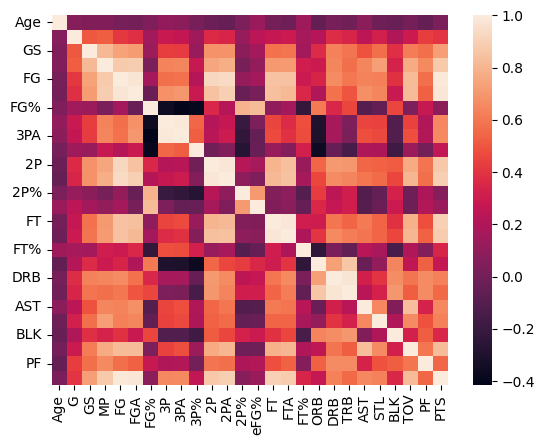

**VIF Table from EDA**

|  | feature | VIF |
| --- | --- | --- |
| 6 | FGA | 9278.338644 |
| 26 | PTS | 6855.495654 |
| 12 | 2PA | 5214.888899 |
| 5 | FG | 4760.500282 |
| 20 | TRB | 2455.633794 |
| 9 | 3PA | 2136.962689 |
| 11 | 2P | 1669.580429 |
| 19 | DRB | 1382.304451 |
| 8 | 3P | 568.795838 |
| 15 | FT | 386.671118 |
| 0 | const | 359.615994 |
| 18 | ORB | 250.011013 |
| 16 | FTA | 85.359677 |
| 7 | FG% | 23.315430 |
| 14 | eFG% | 14.742887 |
| 4 | MP | 12.792623 |
| 24 | TOV | 10.272942 |
| 21 | AST | 5.418226 |
| 13 | 2P% | 4.116444 |
| 3 | GS | 3.556087 |
| 25 | PF | 3.075280 |
| 22 | STL | 2.571860 |
| 23 | BLK | 2.378908 |
| 17 | FT% | 2.192007 |
| 10 | 3P% | 2.185635 |
| 2 | G | 1.627709 |
| 1 | Age | 1.119090 |